# Data Manupulation

A) Data Manipulation: a. Extract the 5th column & store it in ‘customer_5’ b. Extract the 15th column & store it in ‘customer_15’ c. Extract all the male senior citizens whose Payment Method is Electronic check & store the result in ‘senior_male_electronic’ d. Extract all those customers whose tenure is greater than 70 months or their Monthly charges is more than 100$ & store the result in ‘customer_total_tenure’ e. Extract all the customers whose Contract is of two years, payment method is Mailed check & the value of Churn is ‘Yes’ & store the result in ‘two_mail_yes’ f. Extract 333 random records from the customer_churndataframe& store the result in ‘customer_333’ g. Get the count of different levels from the ‘Churn’ column

```python
import pandas as pd
import numpy as np
import matplotlib.pyplot as plt
%matplotlib inline
```

```python
data = pd.read_csv("C:\\Users\\Ranjeet\\Desktop\\Intelpaat\\Files_CSV\\customer_churn.csv")
```

```python
data.head()
```

|  | customerID | gender | SeniorCitizen | Partner | Dependents | tenure | PhoneService | MultipleLines | InternetService | OnlineSecurity | ... | DeviceProtection | TechSupport | StreamingTV | StreamingMovies | Contract | PaperlessBilling | PaymentMethod | MonthlyCharges | TotalCharges | Churn |
| --- | --- | --- | --- | --- | --- | --- | --- | --- | --- | --- | --- | --- | --- | --- | --- | --- | --- | --- | --- | --- | --- |
| 0 | 7590-VHVEG | Female | 0 | Yes | No | 1 | No | No phone service | DSL | No | ... | No | No | No | No | Month-to-month | Yes | Electronic check | 29.85 | 29.85 | No |
| 1 | 5575-GNVDE | Male | 0 | No | No | 34 | Yes | No | DSL | Yes | ... | Yes | No | No | No | One year | No | Mailed check | 56.95 | 1889.5 | No |
| 2 | 3668-QPYBK | Male | 0 | No | No | 2 | Yes | No | DSL | Yes | ... | No | No | No | No | Month-to-month | Yes | Mailed check | 53.85 | 108.15 | Yes |
| 3 | 7795-CFOCW | Male | 0 | No | No | 45 | No | No phone service | DSL | Yes | ... | Yes | Yes | No | No | One year | No | Bank transfer (automatic) | 42.30 | 1840.75 | No |
| 4 | 9237-HQITU | Female | 0 | No | No | 2 | Yes | No | Fiber optic | No | ... | No | No | No | No | Month-to-month | Yes | Electronic check | 70.70 | 151.65 | Yes |

5 rows × 21 columns

```python
data.shape
```

```
(7043, 21)
```

```python
customer_5 = data.iloc[:, 4]
```

```python
customer_5.head()
```

```
0    No
1    No
2    No
3    No
4    No
Name: Dependents, dtype: object
```

```python
customer_15 = data.iloc[:,14]
```

```python
customer_15.head()
```

```
0    No
1    No
2    No
3    No
4    No
Name: StreamingMovies, dtype: object
```

```python
data.head()
```

|  | customerID | gender | SeniorCitizen | Partner | Dependents | tenure | PhoneService | MultipleLines | InternetService | OnlineSecurity | ... | DeviceProtection | TechSupport | StreamingTV | StreamingMovies | Contract | PaperlessBilling | PaymentMethod | MonthlyCharges | TotalCharges | Churn |
| --- | --- | --- | --- | --- | --- | --- | --- | --- | --- | --- | --- | --- | --- | --- | --- | --- | --- | --- | --- | --- | --- |
| 0 | 7590-VHVEG | Female | 0 | Yes | No | 1 | No | No phone service | DSL | No | ... | No | No | No | No | Month-to-month | Yes | Electronic check | 29.85 | 29.85 | No |
| 1 | 5575-GNVDE | Male | 0 | No | No | 34 | Yes | No | DSL | Yes | ... | Yes | No | No | No | One year | No | Mailed check | 56.95 | 1889.5 | No |
| 2 | 3668-QPYBK | Male | 0 | No | No | 2 | Yes | No | DSL | Yes | ... | No | No | No | No | Month-to-month | Yes | Mailed check | 53.85 | 108.15 | Yes |
| 3 | 7795-CFOCW | Male | 0 | No | No | 45 | No | No phone service | DSL | Yes | ... | Yes | Yes | No | No | One year | No | Bank transfer (automatic) | 42.30 | 1840.75 | No |
| 4 | 9237-HQITU | Female | 0 | No | No | 2 | Yes | No | Fiber optic | No | ... | No | No | No | No | Month-to-month | Yes | Electronic check | 70.70 | 151.65 | Yes |

5 rows × 21 columns

```python
senior_male_electronic = data[(data['gender'] == 'Male')& (data['SeniorCitizen'] == 1) & (data['PaymentMethod']=='Electronic check')]
```

```python
senior_male_electronic
```

|  | customerID | gender | SeniorCitizen | Partner | Dependents | tenure | PhoneService | MultipleLines | InternetService | OnlineSecurity | ... | DeviceProtection | TechSupport | StreamingTV | StreamingMovies | Contract | PaperlessBilling | PaymentMethod | MonthlyCharges | TotalCharges | Churn |
| --- | --- | --- | --- | --- | --- | --- | --- | --- | --- | --- | --- | --- | --- | --- | --- | --- | --- | --- | --- | --- | --- |
| 20 | 8779-QRDMV | Male | 1 | No | No | 1 | No | No phone service | DSL | No | ... | Yes | No | No | Yes | Month-to-month | Yes | Electronic check | 39.65 | 39.65 | Yes |
| 55 | 1658-BYGOY | Male | 1 | No | No | 18 | Yes | Yes | Fiber optic | No | ... | No | No | Yes | Yes | Month-to-month | Yes | Electronic check | 95.45 | 1752.55 | Yes |
| 57 | 5067-XJQFU | Male | 1 | Yes | Yes | 66 | Yes | Yes | Fiber optic | No | ... | Yes | Yes | Yes | Yes | One year | Yes | Electronic check | 108.45 | 7076.35 | No |
| 78 | 0191-ZHSKZ | Male | 1 | No | No | 30 | Yes | No | DSL | Yes | ... | No | No | Yes | Yes | Month-to-month | Yes | Electronic check | 74.75 | 2111.3 | No |
| 91 | 2424-WVHPL | Male | 1 | No | No | 1 | Yes | No | Fiber optic | No | ... | No | Yes | No | No | Month-to-month | No | Electronic check | 74.70 | 74.7 | No |
| ... | ... | ... | ... | ... | ... | ... | ... | ... | ... | ... | ... | ... | ... | ... | ... | ... | ... | ... | ... | ... | ... |
| 6837 | 6229-LSCKB | Male | 1 | No | No | 6 | Yes | No | Fiber optic | No | ... | No | No | Yes | No | Month-to-month | Yes | Electronic check | 79.70 | 497.6 | No |
| 6894 | 1400-MMYXY | Male | 1 | Yes | No | 3 | Yes | Yes | Fiber optic | No | ... | Yes | No | Yes | Yes | Month-to-month | Yes | Electronic check | 105.90 | 334.65 | Yes |
| 6914 | 7142-HVGBG | Male | 1 | Yes | No | 43 | Yes | Yes | Fiber optic | No | ... | Yes | No | Yes | Yes | Month-to-month | Yes | Electronic check | 103.00 | 4414.3 | Yes |
| 6967 | 8739-WWKDU | Male | 1 | No | No | 25 | Yes | Yes | Fiber optic | No | ... | No | No | Yes | No | Month-to-month | Yes | Electronic check | 89.50 | 2196.15 | Yes |
| 7032 | 6894-LFHLY | Male | 1 | No | No | 1 | Yes | Yes | Fiber optic | No | ... | No | No | No | No | Month-to-month | Yes | Electronic check | 75.75 | 75.75 | Yes |

298 rows × 21 columns

```python
#d. Extract all those customers whose tenure is greater than 70 months or their
#Monthly charges is more than 100$ & store the result in ‘customer_total_tenure’
customer_total_tenure = data[(data['tenure'] > 70) | (data['MonthlyCharges'] > 100)]
```

```python
customer_total_tenure.head(10)
```

|  | customerID | gender | SeniorCitizen | Partner | Dependents | tenure | PhoneService | MultipleLines | InternetService | OnlineSecurity | ... | DeviceProtection | TechSupport | StreamingTV | StreamingMovies | Contract | PaperlessBilling | PaymentMethod | MonthlyCharges | TotalCharges | Churn |
| --- | --- | --- | --- | --- | --- | --- | --- | --- | --- | --- | --- | --- | --- | --- | --- | --- | --- | --- | --- | --- | --- |
| 8 | 7892-POOKP | Female | 0 | Yes | No | 28 | Yes | Yes | Fiber optic | No | ... | Yes | Yes | Yes | Yes | Month-to-month | Yes | Electronic check | 104.80 | 3046.05 | Yes |
| 12 | 8091-TTVAX | Male | 0 | Yes | No | 58 | Yes | Yes | Fiber optic | No | ... | Yes | No | Yes | Yes | One year | No | Credit card (automatic) | 100.35 | 5681.1 | No |
| 13 | 0280-XJGEX | Male | 0 | No | No | 49 | Yes | Yes | Fiber optic | No | ... | Yes | No | Yes | Yes | Month-to-month | Yes | Bank transfer (automatic) | 103.70 | 5036.3 | Yes |
| 14 | 5129-JLPIS | Male | 0 | No | No | 25 | Yes | No | Fiber optic | Yes | ... | Yes | Yes | Yes | Yes | Month-to-month | Yes | Electronic check | 105.50 | 2686.05 | No |
| 15 | 3655-SNQYZ | Female | 0 | Yes | Yes | 69 | Yes | Yes | Fiber optic | Yes | ... | Yes | Yes | Yes | Yes | Two year | No | Credit card (automatic) | 113.25 | 7895.15 | No |
| 17 | 9959-WOFKT | Male | 0 | No | Yes | 71 | Yes | Yes | Fiber optic | Yes | ... | Yes | No | Yes | Yes | Two year | No | Bank transfer (automatic) | 106.70 | 7382.25 | No |
| 28 | 5248-YGIJN | Male | 0 | Yes | No | 72 | Yes | Yes | DSL | Yes | ... | Yes | Yes | Yes | Yes | Two year | Yes | Credit card (automatic) | 90.25 | 6369.45 | No |
| 30 | 3841-NFECX | Female | 1 | Yes | No | 71 | Yes | Yes | Fiber optic | Yes | ... | Yes | Yes | No | No | Two year | Yes | Credit card (automatic) | 96.35 | 6766.95 | No |
| 35 | 6234-RAAPL | Female | 0 | Yes | Yes | 72 | Yes | Yes | Fiber optic | Yes | ... | No | Yes | Yes | No | Two year | No | Bank transfer (automatic) | 99.90 | 7251.7 | No |
| 38 | 5380-WJKOV | Male | 0 | No | No | 34 | Yes | Yes | Fiber optic | No | ... | Yes | No | Yes | Yes | Month-to-month | Yes | Electronic check | 106.35 | 3549.25 | Yes |

10 rows × 21 columns

```python
#e. Extract all the customers whose Contract is of two years, payment method is Mailed
#check & the value of Churn is ‘Yes’ & store the result in ‘two_mail_yes’
two_mail_yes = data[(data['Contract']=='Two year') & (data['PaymentMethod']=='Mailed check') & (data['Churn']=='Yes')]
```

```python
two_mail_yes.head()
```

|  | customerID | gender | SeniorCitizen | Partner | Dependents | tenure | PhoneService | MultipleLines | InternetService | OnlineSecurity | ... | DeviceProtection | TechSupport | StreamingTV | StreamingMovies | Contract | PaperlessBilling | PaymentMethod | MonthlyCharges | TotalCharges | Churn |
| --- | --- | --- | --- | --- | --- | --- | --- | --- | --- | --- | --- | --- | --- | --- | --- | --- | --- | --- | --- | --- | --- |
| 268 | 6323-AYBRX | Male | 0 | No | No | 59 | Yes | No | No | No internet service | ... | No internet service | No internet service | No internet service | No internet service | Two year | No | Mailed check | 19.35 | 1099.6 | Yes |
| 5947 | 7951-QKZPL | Female | 0 | Yes | Yes | 33 | Yes | Yes | No | No internet service | ... | No internet service | No internet service | No internet service | No internet service | Two year | Yes | Mailed check | 24.50 | 740.3 | Yes |
| 6680 | 9412-ARGBX | Female | 0 | No | Yes | 48 | Yes | No | Fiber optic | No | ... | Yes | Yes | Yes | No | Two year | Yes | Mailed check | 95.50 | 4627.85 | Yes |

3 rows × 21 columns

```python
#f. Extract 333 random records from the customer_churndataframe& store the result in
#‘customer_333’
customer_333 = data.sample(n=333)
```

```python
customer_333.head()
```

|  | customerID | gender | SeniorCitizen | Partner | Dependents | tenure | PhoneService | MultipleLines | InternetService | OnlineSecurity | ... | DeviceProtection | TechSupport | StreamingTV | StreamingMovies | Contract | PaperlessBilling | PaymentMethod | MonthlyCharges | TotalCharges | Churn |
| --- | --- | --- | --- | --- | --- | --- | --- | --- | --- | --- | --- | --- | --- | --- | --- | --- | --- | --- | --- | --- | --- |
| 5230 | 5887-IKKYO | Male | 0 | Yes | Yes | 58 | Yes | Yes | Fiber optic | No | ... | Yes | Yes | No | Yes | Two year | No | Bank transfer (automatic) | 94.35 | 5563.65 | No |
| 1271 | 4598-ZADCK | Female | 0 | No | No | 53 | No | No phone service | DSL | Yes | ... | Yes | Yes | Yes | No | One year | Yes | Electronic check | 53.60 | 2879.2 | No |
| 3409 | 4806-DXQCE | Female | 1 | Yes | No | 70 | Yes | Yes | Fiber optic | Yes | ... | Yes | Yes | Yes | Yes | Two year | Yes | Electronic check | 113.65 | 7714.65 | No |
| 62 | 0526-SXDJP | Male | 0 | Yes | No | 72 | No | No phone service | DSL | Yes | ... | Yes | No | No | No | Two year | No | Bank transfer (automatic) | 42.10 | 2962 | No |
| 4473 | 2665-NPTGL | Female | 1 | Yes | No | 26 | Yes | Yes | Fiber optic | No | ... | Yes | No | Yes | Yes | Month-to-month | Yes | Bank transfer (automatic) | 98.10 | 2510.7 | No |

5 rows × 21 columns

```python
customer_333.info()
```

```
<class 'pandas.core.frame.DataFrame'>
Int64Index: 333 entries, 5230 to 4056
Data columns (total 21 columns):
 #   Column            Non-Null Count  Dtype
---  ------            --------------  -----
 0   customerID        333 non-null    object
 1   gender            333 non-null    object
 2   SeniorCitizen     333 non-null    int64
 3   Partner           333 non-null    object
 4   Dependents        333 non-null    object
 5   tenure            333 non-null    int64
 6   PhoneService      333 non-null    object
 7   MultipleLines     333 non-null    object
 8   InternetService   333 non-null    object
 9   OnlineSecurity    333 non-null    object
 10  OnlineBackup      333 non-null    object
 11  DeviceProtection  333 non-null    object
 12  TechSupport       333 non-null    object
 13  StreamingTV       333 non-null    object
 14  StreamingMovies   333 non-null    object
 15  Contract          333 non-null    object
 16  PaperlessBilling  333 non-null    object
 17  PaymentMethod     333 non-null    object
 18  MonthlyCharges    333 non-null    float64
 19  TotalCharges      333 non-null    object
 20  Churn             333 non-null    object
dtypes: float64(1), int64(2), object(18)
memory usage: 57.2+ KB
```

```python
#g. Get the count of different levels from the ‘Churn’ column
data['Churn'].value_counts()
```

```
No     5174
Yes    1869
Name: Churn, dtype: int64
```

# Data Visualization

a. Build a bar-plot for the ’InternetService’ column: i. Set x-axis label to ‘Categories of Internet Service’ ii. Set y-axis label to ‘Count of Categories’ iii. Set the title of plot to be ‘Distribution of Internet Service’ iv. Set the color of the bars to be ‘orange’

```python
data.head()
```

|  | customerID | gender | SeniorCitizen | Partner | Dependents | tenure | PhoneService | MultipleLines | InternetService | OnlineSecurity | ... | DeviceProtection | TechSupport | StreamingTV | StreamingMovies | Contract | PaperlessBilling | PaymentMethod | MonthlyCharges | TotalCharges | Churn |
| --- | --- | --- | --- | --- | --- | --- | --- | --- | --- | --- | --- | --- | --- | --- | --- | --- | --- | --- | --- | --- | --- |
| 0 | 7590-VHVEG | Female | 0 | Yes | No | 1 | No | No phone service | DSL | No | ... | No | No | No | No | Month-to-month | Yes | Electronic check | 29.85 | 29.85 | No |
| 1 | 5575-GNVDE | Male | 0 | No | No | 34 | Yes | No | DSL | Yes | ... | Yes | No | No | No | One year | No | Mailed check | 56.95 | 1889.5 | No |
| 2 | 3668-QPYBK | Male | 0 | No | No | 2 | Yes | No | DSL | Yes | ... | No | No | No | No | Month-to-month | Yes | Mailed check | 53.85 | 108.15 | Yes |
| 3 | 7795-CFOCW | Male | 0 | No | No | 45 | No | No phone service | DSL | Yes | ... | Yes | Yes | No | No | One year | No | Bank transfer (automatic) | 42.30 | 1840.75 | No |
| 4 | 9237-HQITU | Female | 0 | No | No | 2 | Yes | No | Fiber optic | No | ... | No | No | No | No | Month-to-month | Yes | Electronic check | 70.70 | 151.65 | Yes |

5 rows × 21 columns

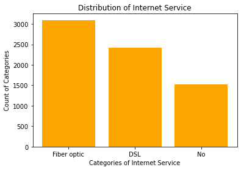

```python
x = data["InternetService"].value_counts().keys()
y = data["InternetService"].value_counts()
plt.bar(x,y, color = 'orange')
plt.xlabel("Categories of Internet Service")
plt.ylabel("Count of Categories")
plt.title("Distribution of Internet Service")
plt.show()
```

# b. Build a histogram for the ‘tenure’ column: i. Set the number of bins to be 30 ii. Set the color of the bins to be ‘green’ iii. Assign the title ‘Distribution of tenure’

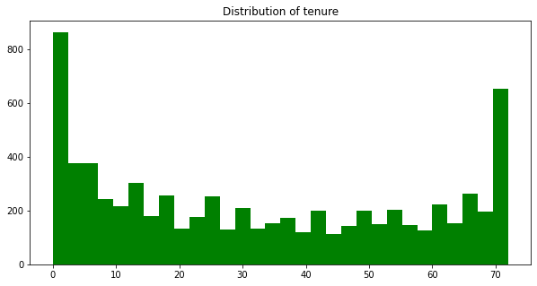

```python
fig = plt.figure(figsize=(10,5))
plt.hist(data["tenure"], bins=30, color='green')
plt.title("Distribution of tenure")
plt.show()
```

[figure not shown]

```python
x = data["MonthlyCharges"].head(50)
y = data["tenure"].head(50)

plt.scatter(x,y, color='brown')
plt.xlabel("Tenure of customer")
plt.ylabel("Monthly Charges of customer")
plt.title("Tenure vs Monthly Charges")
plt.show()
```

# d. Build a box-plot between ‘tenure’ & ‘Contract’. Map ‘tenure’ on the y-axis & ‘Contract’ on the x-axis.

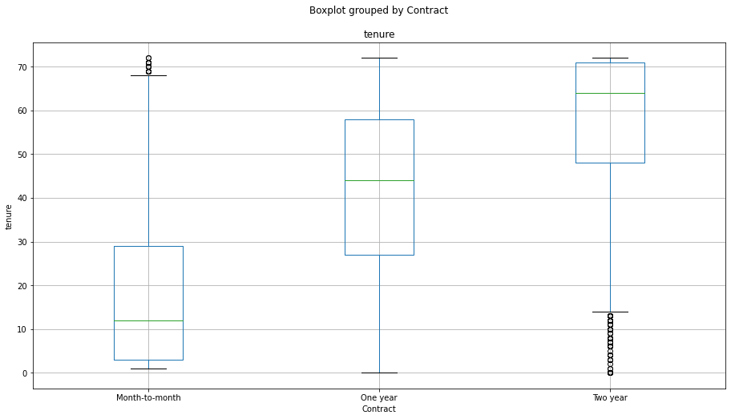

```python
data.boxplot(column=["tenure"], by=["Contract"], figsize=(15,8))
plt.xlabel("Contract")
plt.ylabel("tenure")
plt.show()
```

# Linear Regression

```python
from sklearn.model_selection import train_test_split
from sklearn.metrics import mean_squared_error, accuracy_score, r2_score
from sklearn.linear_model import LinearRegression
```

```python
data.head()
```

|  | customerID | gender | SeniorCitizen | Partner | Dependents | tenure | PhoneService | MultipleLines | InternetService | OnlineSecurity | ... | DeviceProtection | TechSupport | StreamingTV | StreamingMovies | Contract | PaperlessBilling | PaymentMethod | MonthlyCharges | TotalCharges | Churn |
| --- | --- | --- | --- | --- | --- | --- | --- | --- | --- | --- | --- | --- | --- | --- | --- | --- | --- | --- | --- | --- | --- |
| 0 | 7590-VHVEG | Female | 0 | Yes | No | 1 | No | No phone service | DSL | No | ... | No | No | No | No | Month-to-month | Yes | Electronic check | 29.85 | 29.85 | No |
| 1 | 5575-GNVDE | Male | 0 | No | No | 34 | Yes | No | DSL | Yes | ... | Yes | No | No | No | One year | No | Mailed check | 56.95 | 1889.5 | No |
| 2 | 3668-QPYBK | Male | 0 | No | No | 2 | Yes | No | DSL | Yes | ... | No | No | No | No | Month-to-month | Yes | Mailed check | 53.85 | 108.15 | Yes |
| 3 | 7795-CFOCW | Male | 0 | No | No | 45 | No | No phone service | DSL | Yes | ... | Yes | Yes | No | No | One year | No | Bank transfer (automatic) | 42.30 | 1840.75 | No |
| 4 | 9237-HQITU | Female | 0 | No | No | 2 | Yes | No | Fiber optic | No | ... | No | No | No | No | Month-to-month | Yes | Electronic check | 70.70 | 151.65 | Yes |

5 rows × 21 columns

```python
data.columns
```

```
Index(['customerID', 'gender', 'SeniorCitizen', 'Partner', 'Dependents',
       'tenure', 'PhoneService', 'MultipleLines', 'InternetService',
       'OnlineSecurity', 'OnlineBackup', 'DeviceProtection', 'TechSupport',
       'StreamingTV', 'StreamingMovies', 'Contract', 'PaperlessBilling',
       'PaymentMethod', 'MonthlyCharges', 'TotalCharges', 'Churn'],
      dtype='object')
```

a. Build a simple linear model where dependent variable is ‘MonthlyCharges’ and independent variable is ‘tenure’ i. Divide the dataset into train and test sets in 70:30 ratio. ii. Build the model on train set and predict the values on test set iii. After predicting the values, find the root mean square error iv. Find out the error in prediction & store the result in ‘error’ v. Find the root mean square error

```python
x = pd.DataFrame(data["tenure"])
y = data["MonthlyCharges"]
```

```python
x_train, x_test, y_train, y_test = train_test_split(x,y, test_size=.3, random_state=0)
```

```python
model = LinearRegression()
```

```python
model.fit(x_train, y_train)
```

```
LinearRegression()
```

```python
test_pred = model.predict(x_test)
```

```python
mse = mean_squared_error(y_test, test_pred)
```

```python
error = np.sqrt(mse)
```

```python
error
```

```
29.394584027273893
```

# Logistic Regression

```python
from sklearn.linear_model import LogisticRegression
from sklearn.metrics import accuracy_score, confusion_matrix,f1_score
```

a. Build a simple logistic regression modelwhere dependent variable is ‘Churn’ & independent variable is ‘MonthlyCharges’ i. Divide the dataset in 65:35 ratio ii. Build the model on train set and predict the values on test set iii. Build the confusion matrix and get the accuracy score

```python
x = pd.DataFrame(data["MonthlyCharges"])
y = data["Churn"]
```

```python
x_train, x_test, y_train, y_test = train_test_split(x,y, test_size=0.35, random_state=0)
```

```python
model = LogisticRegression()
```

```python
model.fit(x_train, y_train)
```

```
LogisticRegression()
```

```python
test_predL = model.predict(x_test)
```

```python
confusion_matrix(y_test, test_predL)
```

```
array([[1815,    0],
       [ 651,    0]], dtype=int64)
```

```python
accuracy_score(y_test, test_predL)
```

```
0.7360097323600974
```

```python
x = pd.DataFrame(data["MonthlyCharges"], data["tenure"])
y = data["Churn"]
```

```python
x
```

| tenure | MonthlyCharges |
| --- | --- |
| 1 | 56.95 |
| 34 | 45.25 |
| 2 | 53.85 |
| 45 | 84.50 |
| 2 | 53.85 |
| ... | ... |
| 24 | 59.60 |
| 72 | 111.60 |
| 11 | 18.95 |
| 4 | 70.70 |
| 66 | 78.90 |

7043 rows × 1 columns

```python
x_train, x_test, y_train, y_test = train_test_split(x,y, test_size=0.2, random_state=0)
```

```python
model = LogisticRegression()
```

```python
model.fit(x_train, y_train)
```

```
LogisticRegression()
```

```python
test_predB = model.predict(x_test)
```

```python
confusion_matrix(y_test, test_predB)
```

```
array([[1041,    0],
       [ 368,    0]], dtype=int64)
```

```python
accuracy_score(y_test, test_predB)
```

```
0.7388218594748048
```

```python
f1_score(y_test, test_predB, average=None)
```

```
array([0.84979592, 0.        ])
```

# Decision Tree:

```python
from sklearn.tree import DecisionTreeClassifier
```

a. Build a decision tree model where dependent variable is ‘Churn’ & independent variable is ‘tenure’ i. Divide the dataset in 80:20 ratio ii. Build the model on train set and predict the values on test set iii. Build the confusion matrix and calculate the accuracy

```python
x = pd.DataFrame(data["tenure"])
y = data["Churn"]
```

```python
x_train, x_test, y_train, y_test = train_test_split(x,y, test_size=0.2, random_state=0)
```

```python
model = DecisionTreeClassifier(max_depth=4)
```

```python
model.fit(x_train, y_train)
```

```
DecisionTreeClassifier(max_depth=4)
```

```python
test_predD = model.predict(x_test)
```

```python
confusion_matrix(y_test, test_predD)
```

```
array([[965,  76],
       [281,  87]], dtype=int64)
```

```python
accuracy_score(y_test, test_predD)
```

```
0.7466288147622427
```

```python
f1_score(y_test, test_predD, average=None)
```

```
array([0.84390031, 0.32768362])
```

# Random Forest:

```python
from sklearn.ensemble import RandomForestClassifier
```

```python
x = pd.DataFrame(data["MonthlyCharges"], data["tenure"])
y = data["Churn"]
```

```python
x_train, x_test, y_train, y_test = train_test_split(x,y, test_size=0.3, random_state=0)
```

```python
model = RandomForestClassifier(max_depth=2)
```

```python
model.fit(x_train, y_train)
```

```
RandomForestClassifier(max_depth=2)
```

```python
test_predR = model.predict(x_test)
```

```python
confusion_matrix(y_test, test_predR)
```

```
array([[1484,   76],
       [ 449,  104]], dtype=int64)
```

```python
accuracy_score(y_test, test_predR)
```

```
0.751538097491718
```